# nonlinearTseries quickstart

Constantino Antonio García Martínez

2015-05-26

The **nonlinearTseries** package provides functionality for nonlinear time series analysis. This package permits the estimation of the most-used nonlinear sstatistics/algorithms including generalized correlation dimension, information dimension, largest Lyapunov exponent, sample entropy and Recurrence Quantification Analysis (RQA), among others. Basic routines for surrogate data testing are also included. This vignette provides a brief overview of some of the functionality contained in **nonlinearTseries**.

## Data: Lorenz system

To explore the routines included in **nonlinearTseries**, we will study the famous [Lorenz system](http://en.wikipedia.org/wiki/Lorenz_system). **nonlinearTseries** offers different routines for simulating the best well-known nonlinear systems:

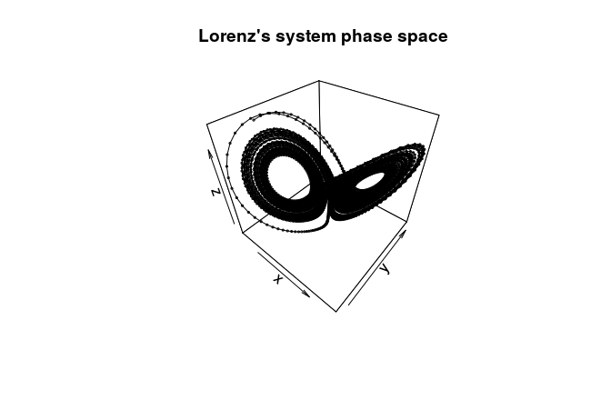

```r
suppressMessages(library('nonlinearTseries'))
library('plot3D')
# by default, the simulation creates a RGL plot of the system's phase space
lor = lorenz(do.plot = F)
# let's plot the phase space of the simulated lorenz system
scatter3D(lor$x, lor$y, lor$z,
          main = "Lorenz's system phase space",
          col = 1, type="o",cex = 0.3)
```

It must be noted that the `lorenz` function returns the simulated components of the system in a `list`. Future versions of the package will allow to obtain the same simulations as `ts` objects.

## Taken’s embedding theorem

Usually, what we observe in a physical experiment is a single time series and not the completely phase space. For example, imagine that we have only measured the x component of the Lorenz system. Fortunately, we can still infer the properties of the phase space by constructing vectors whose components are time delayed versions of the x signal $[x(t), x(t+\tau), ..., x(t + m\tau)]$ (This theoretical result is referred to as the [Takens’ embedding theorem](http://www.scholarpedia.org/article/Attractor_reconstruction)).

The **nonlinearTseries** package provides functions for estimating proper values for the embedding dimension $m$ and the delay-parameter $\tau$. First, the delay-parameter can be estimated by using the autocorrelation function or the average mutual information of the signal.

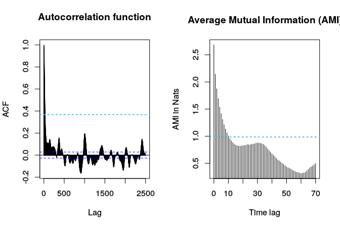

```r
# Imagine we have only measured the x-component of the Lorenz system
lor.x = lor$x

old.par = par(mfrow = c(1, 2))
# tau-delay estimation based on the autocorrelation function
tau.acf = timeLag(lor.x, technique = "acf", do.plot = T)
# tau-delay estimation based on the mutual information function
tau.ami = timeLag(lor.x, technique = "ami", do.plot = T)
par(old.par)
```

Both techniques select a time-lag based on the behaviour of the autocorrelation or the average mutual information function. Since the autocorrelation function is a linear statistic we usually obtain more appropriate values with the mutual information technique. Thus, for the remainder of this section, we will use the value obtained with this technique.

Once the time-lag parameter has been estimated, a proper embedding dimension can be computed by using the well-known Cao’s algorithm ((Cao 1997)see `?estimateEmbeddingDim` for references):

```r
emb.dim = estimateEmbeddingDim(lor.x, time.lag = tau.ami,
                               max.embedding.dim = 15)
```

[figure not shown]

The final phase space reconstruction can be obtained using the `buildTakens` function:

```r
tak = buildTakens(lor.x,embedding.dim = emb.dim, time.lag = tau.ami)
scatter3D(tak[,1], tak[,2], tak[,3],
          main = "Lorenz's system reconstructed phase space",
          col = 1, type="o",cex = 0.3)
```

[figure not shown]

Note that the reconstructed and the original phase space have similar features.

## Lyapunov exponent and dimensions

### Correlation dimension

```
## expected: 2.05  --- estimate:  2.000255
```

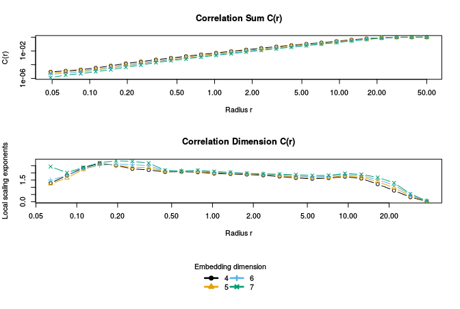

```r
cd = corrDim(lor.x,
             min.embedding.dim = emb.dim,
             max.embedding.dim = emb.dim + 3,
             time.lag = tau.ami,
             min.radius = 0.001, max.radius = 50,
             n.points.radius = 40, theiler.window = 100,
             do.plot=FALSE)
plot(cd)
cd.est = estimate(cd,regression.range=c(0.75,3),use.embeddings = 5:7)
cat("expected: 2.05  --- estimate: ",cd.est,"\n")
```

## Surrogate data testing

Although we have postponed its discussion until the end of this vignette, the first step before studying a system using nonlinear analysis techniques should be checking that the data shows indeed some degree of nonlinearity.

The preferred method for nonlinearity-test in literature is surrogate data testing. In surrogate data testing, a statistic $\mu$ quantifying some nonlinear feature of the data is computed and compared with the resulting values for an ensamble of comparable linear processes (Theiler et al. 1992). **nonlinearTseries** includes basic functionality for surrogate data testing. The next example performs surrogate data testing by measuring the time asymmetry of the data and the surrogates (since linear stochastic processes are symmetric under time reversal, a deviation from the distribution of the surrogates will be a strong sign of nonlinearity). From the resulting figure, it is clear that our time series shows some degree of nonlinearity.

```r
st = surrogateTest(lor.x,significance = 0.05,one.sided = F,
                   FUN = timeAsymmetry, do.plot=F)
```

```
## Computing statistics
##
## Null Hypothesis: Data comes from a linear stochastic process
## Reject Null hypothesis:
##      Original data's stat is significant larger than surrogates' stats
```

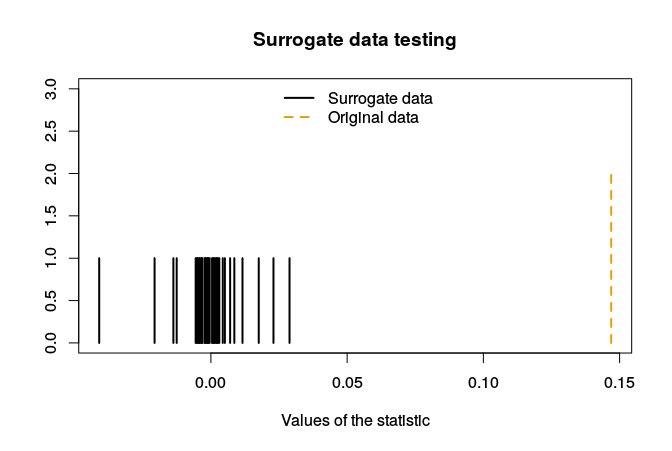

```r
plot(st)
```

References

Cao, Liangyue. 1997. “Practical Method for Determining the Minimum Embedding Dimension of a Scalar Time Series.” *Physica D: Nonlinear Phenomena* 110 (1). Elsevier: 43–50.

Theiler, James, Stephen Eubank, André Longtin, Bryan Galdrikian, and J Doyne Farmer. 1992. “Testing for Nonlinearity in Time Series: The Method of Surrogate Data.” *Physica D: Nonlinear Phenomena* 58 (1). Elsevier: 77–94.